# Assignment 5

# 1 Estimate a Lasso model of FamilyIncome from the acs data at https://www.jaredlander.com/data/acs_ny.csv (Links to an external site.)Links to an external site. (use read.table to read the data since it works better for this file than read_csv).

```r
library(magrittr)

library(glmnet)

income_data <- read.table(file='https://www.jaredlander.com/data/acs_ny.csv', header=TRUE, sep=',')
head(income_data)
```

```
##   Acres FamilyIncome  FamilyType NumBedrooms NumChildren NumPeople
## 1  1-10          150     Married           4           1         3
## 2  1-10          180 Female Head           3           2         4
## 3  1-10          280 Female Head           4           0         2
## 4  1-10          330 Female Head           2           1         2
## 5  1-10          330   Male Head           3           1         2
## 6  1-10          480   Male Head           0           3         4
##   NumRooms        NumUnits NumVehicles NumWorkers  OwnRent   YearBuilt
## 1        9 Single detached           1          0 Mortgage   1950-1959
## 2        6 Single detached           2          0   Rented Before 1939
## 3        8 Single detached           3          1 Mortgage   2000-2004
## 4        4 Single detached           1          0   Rented   1950-1959
## 5        5 Single attached           1          0 Mortgage Before 1939
## 6        1 Single detached           0          0   Rented Before 1939
##   HouseCosts ElectricBill FoodStamp HeatingFuel Insurance       Language
## 1       1800           90        No         Gas      2500        English
## 2        850           90        No         Oil         0        English
## 3       2600          260        No         Oil      6600 Other European
## 4       1800          140        No         Oil         0        English
## 5        860          150        No         Gas       660        Spanish
## 6        700          140        No         Gas         0        English
```

## 1.1 Use the cross-validated Lasso function (cv.glmnet) in the glmnet package, and the build.x and build.y functions in the useful package as shown in class. Do not include FoodStamp as a predictor.

```r
incomeFormula <- FamilyIncome ~ Acres + FamilyType + NumBedrooms + NumChildren + NumPeople + NumRooms + NumUnits + NumVehicles + NumWorkers + OwnRent + YearBuilt + HouseCosts + ElectricBill + HeatingFuel + Insurance + Language - 1

incomeX_train <- build.x(incomeFormula, data=income_data,
                      contrast=FALSE, sparse=TRUE)

incomeY_train <- build.y(incomeFormula, data=income_data)

income1 <- cv.glmnet(x=incomeX_train, y=incomeY_train, family='gaussian', nfolds=5, alpha=1)
```

## 1.2 Plot the cross-validation curve and comment on what it represents.

[figure not shown]

```r
library(coefplot)
plot(income1)
```

## Plot the shrinkage path and comment on what this plot represents.

```r
coefpath(income1)
```

[interactive chart not shown]

```r
# this plot shows the weights of the variables at different lambdas. As lambda increases, they shrink towards zero.
```

# 2 For the above estimated model, which variables does Lasso select under lambda.min and lambda.1se? Present coeﬃcients for both models. Which one selects fewer variables and why? Show the coefplot for both values of lambda.

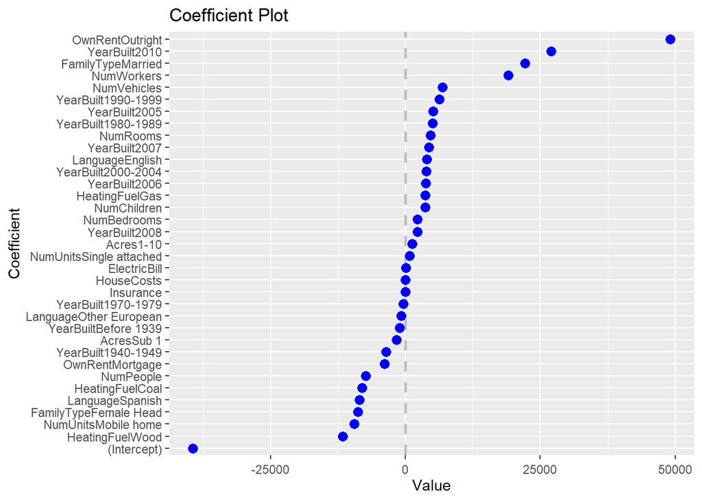

```r
library(coefplot)

coefplot(income1, sort='magnitude', lambda='lambda.min')
```

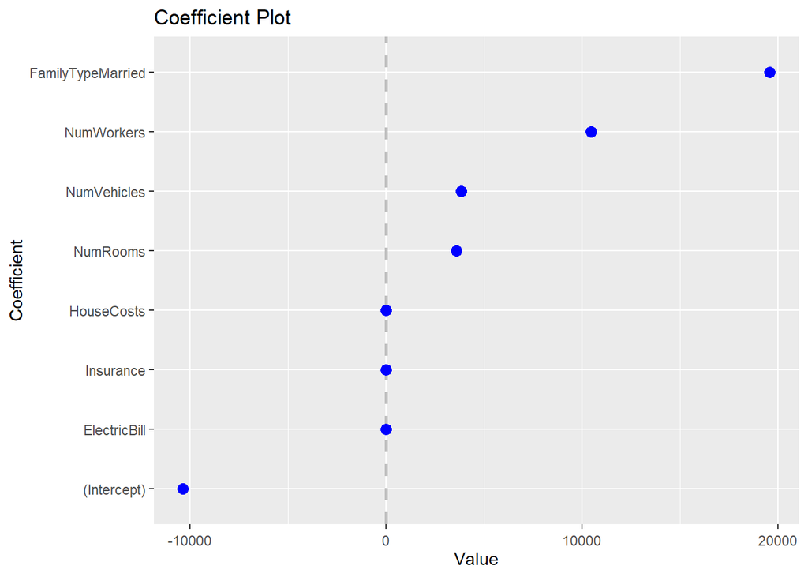

```r
library(coefplot)

coefplot(income1, sort='magnitude', lambda='lambda.1se')
```

## 2.1 Present both the lambda values from the above estimated model. In your own words what do these parameters represent?

```r
library(coefplot)

income1$lambda.min
```

```
## [1] 232.9023
```

```r
library(coefplot)

income1$lambda.1se
```

```
## [1] 6633.142
```

```r
# the first of these values represents the value of lambda, the appropriate shrinkage, that produces the lowest mean squared error on the model and the values of the coefficients at that lambda.
# The second value is the highest level of shrinkage that is still within 1 standard error of the first model; this model has fewer variables and is simpler.
```

# 3 Estimate a Ridge model of the same dataset as before.

```r
library(coefplot)

income2 <- cv.glmnet(x=incomeX_train, y=incomeY_train, family='gaussian', nfolds=5, alpha=0)
coefpath(income2)
```

[interactive chart not shown]

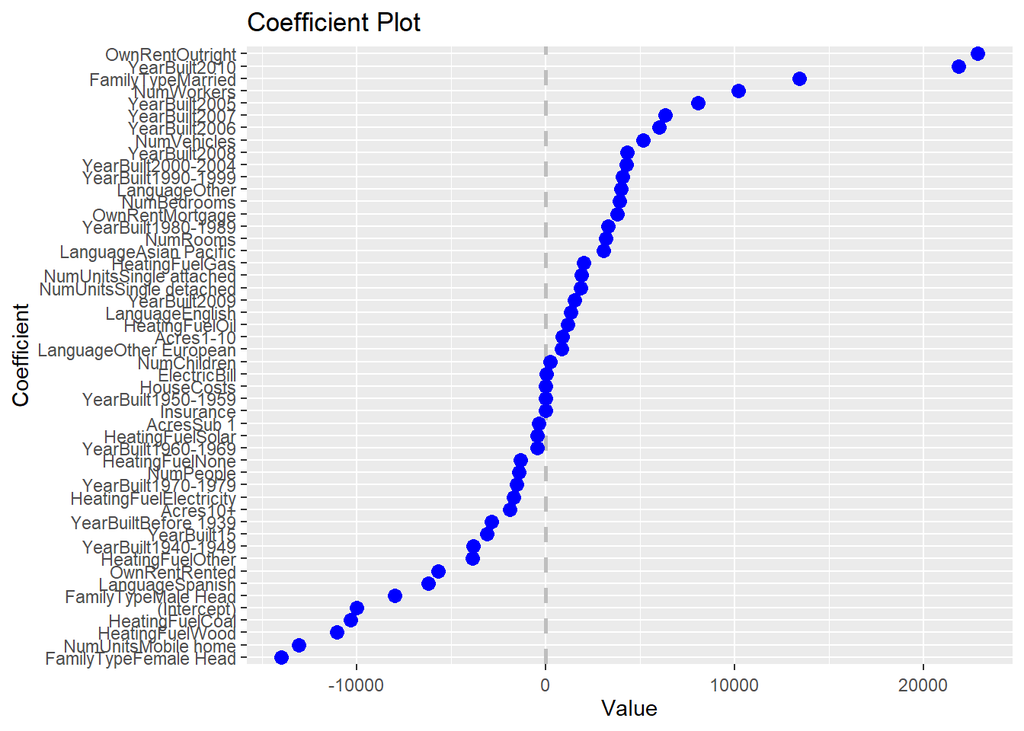

```r
library(coefplot)

coefplot(income2, sort='magnitude', lambda='lambda.1se')
```

# 4 Estimate a boosted tree model over the same data as before. Since this is for continuous data be sure to set appropriate objective and eval_metric arguments. Use a random portion of the data as a validation set for the watchlist. Also see which settings for max_depth, eta and nrounds work best based on validation error.

```r
library(useful)
library(xgboost)

# create sample size of 20% for validation

samp.size = floor(0.8 * nrow(income_data))
train.ind <- sample(seq_len(nrow(income_data)), size = samp.size)
income_train = income_data[train.ind, ]
income_val = income_data[-train.ind, ]

incomeX_train = build.x(incomeFormula, data=income_train, contrasts=FALSE, sparse=TRUE)
incomeY_train = build.y(incomeFormula, data=income_train)

incomeX_val = build.x(incomeFormula, data=income_val, contrasts=FALSE, sparse=TRUE)
incomeY_val = build.y(incomeFormula, data=income_val)

xgTrain <- xgb.DMatrix(data=incomeX_train, label=incomeY_train) # holds x and y matrices

xgVal <- xgb.DMatrix(data=incomeX_val, label=incomeY_val)

incomeBoost <- xgb.train(
    data=xgTrain,
    objective='reg:linear',
    nrounds=400,
    eval_metric='rmse',
    eta=0.1,
    max_depth=4,
    watchlist=list(train=xgTrain, validate=xgVal),
    early_stopping_rounds=50
)
```

[output not shown]

## 4.1 Create a variable importance plot and comment on the top three predictors. Plot the training and validation loss (stored in the evaluation_log slot of the model) with dygraphs.

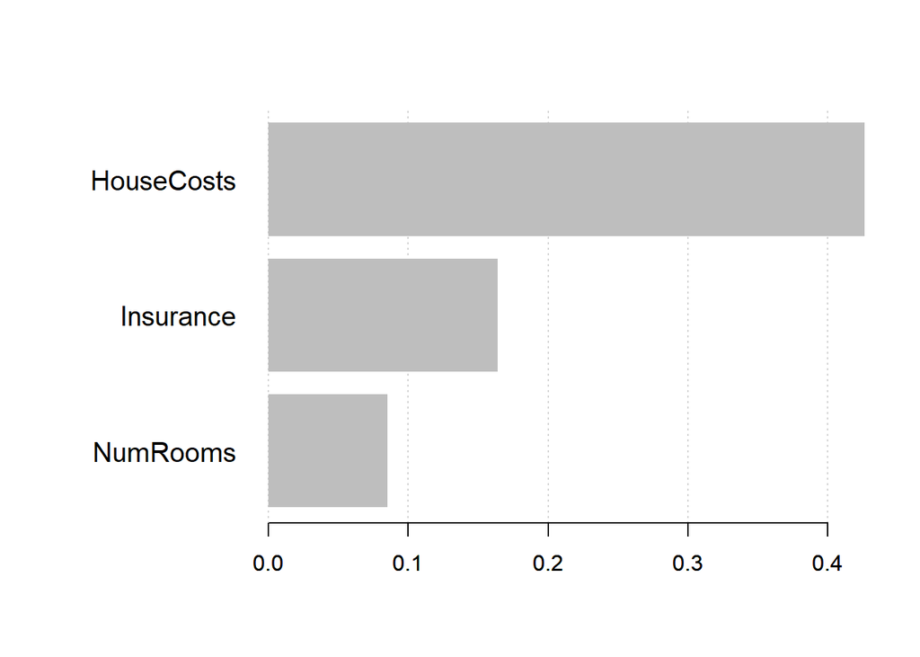

```r
library(xgboost)

xgb.plot.importance(xgb.importance(incomeBoost, feature_names=colnames(incomeX_train)), top_n = 3)
```

## Plot the training and validation loss (stored in the evaluation_log slot of the model) with dygraphs.

```r
library(dygraphs)

dygraph(incomeBoost$evaluation_log)
```

[interactive chart not shown]

# Download the 2015 NFL Play-by-Play data from https://www.jaredlander.com/data/pbp-2015.csv (Links to an external site.)Links to an external site.

```r
play_data <- read.table(file='https://www.jaredlander.com/data/pbp-2015.csv', header=TRUE, sep=',')
head(play_data)
```

```
##       GameId   GameDate Quarter Minute Second OffenseTeam DefenseTeam Down
## 1 2015091000 2015-09-10       2      2      0                     PIT    0
## 2 2015091300 2015-09-13       3      4     50                      GB    0
## 3 2015091300 2015-09-13       4      0      0                      GB    0
## 4 2015091301 2015-09-13       2      2      0                     SEA    0
## 5 2015091302 2015-09-13       1      0      0                     CAR    0
## 6 2015091303 2015-09-13       2      9     48         WAS         MIA    2
##   ToGo YardLine  X SeriesFirstDown X.1 NextScore
## 1    0        0 NA               1  NA         0
## 2    0        0 NA               1  NA         0
## 3    0        0 NA               1  NA         0
## 4    0        0 NA               1  NA         0
## 5    0        0 NA               1  NA         0
## 6    2       20 NA               1  NA         0
##                                                         Description
```

[output cut: 48 more lines]

```r
names(play_data)
```

```
##  [1] "GameId"                         "GameDate"
##  [3] "Quarter"                        "Minute"
##  [5] "Second"                         "OffenseTeam"
##  [7] "DefenseTeam"                    "Down"
##  [9] "ToGo"                           "YardLine"
## [11] "X"                              "SeriesFirstDown"
## [13] "X.1"                            "NextScore"
## [15] "Description"                    "TeamWin"
## [17] "X.2"                            "X.3"
## [19] "SeasonYear"                     "Yards"
## [21] "Formation"                      "PlayType"
## [23] "IsRush"                         "IsPass"
## [25] "IsIncomplete"                   "IsTouchdown"
## [27] "PassType"                       "IsSack"
## [29] "IsChallenge"                    "IsChallengeReversed"
## [31] "Challenger"                     "IsMeasurement"
## [33] "IsInterception"                 "IsFumble"
## [35] "IsPenalty"                      "IsTwoPointConversion"
## [37] "IsTwoPointConversionSuccessful" "RushDirection"
## [39] "YardLineFixed"                  "YardLineDirection"
## [41] "IsPenaltyAccepted"              "PenaltyTeam"
## [43] "IsNoPlay"                       "PenaltyType"
## [45] "PenaltyYards"
```

## 4.2 Filter the data down to just one team and when PlayType is either ‘RUSH’ or ‘PASS’ and convert those to 0 and 1. Using a number of columns, create the appropriate X and Y matrices and xgb.DMatrix objects to fit an XGBoost model. Use a random portion of the data as a validation set for the watchlist. Be sure to set appropriate objective and eval_metric arguments and choose good max_depth, eta and nrounds settings.

```r
library(dplyr)

# Get data
play_data <- play_data %>%
    filter(OffenseTeam == "PHI") %>%
    filter(PlayType %in% c('RUSH', 'PASS')) %>%
    mutate(RorP = ifelse(PlayType == 'RUSH', 0, 1))
table(play_data$RorP) # 50% more likely to pass overall
```

```
##
##   0   1
## 422 660
```

```r
library(useful)
library(xgboost)

# split the data into train & val sets
samp.size = floor(0.8 * nrow(play_data))
train.ind <- sample(seq_len(nrow(play_data)), size = samp.size)
play_train = play_data[train.ind, ]
play_val = play_data[-train.ind, ]

# make formula
playFormula <- RorP ~ Quarter + Minute + DefenseTeam + Down + ToGo + YardLine + SeriesFirstDown + SeasonYear + Formation

playX_train = build.x(playFormula, data=play_train, contrasts=FALSE, sparse=TRUE)
playY_train = build.y(playFormula, data=play_train)

playX_val = build.x(playFormula, data=play_val, contrasts=FALSE, sparse=TRUE)
playY_val = build.y(playFormula, data=play_val)

xgPlayTrain <- xgb.DMatrix(data=playX_train, label=playY_train) # holds x and y matrices

xgPlayVal <- xgb.DMatrix(data=playX_val, label=playY_val)

playBoost <- xgb.train(
    data=xgPlayTrain,
    objective='binary:logistic',
    nrounds=500,
    eval_metric='rmse',
    eta=0.15,
    max_depth=3,
    watchlist=list(train=xgPlayTrain, validate=xgPlayVal),
    early_stopping_rounds = 20
)
```

[output not shown]

## 4.3 Plot variable importance and the training and validation loss.

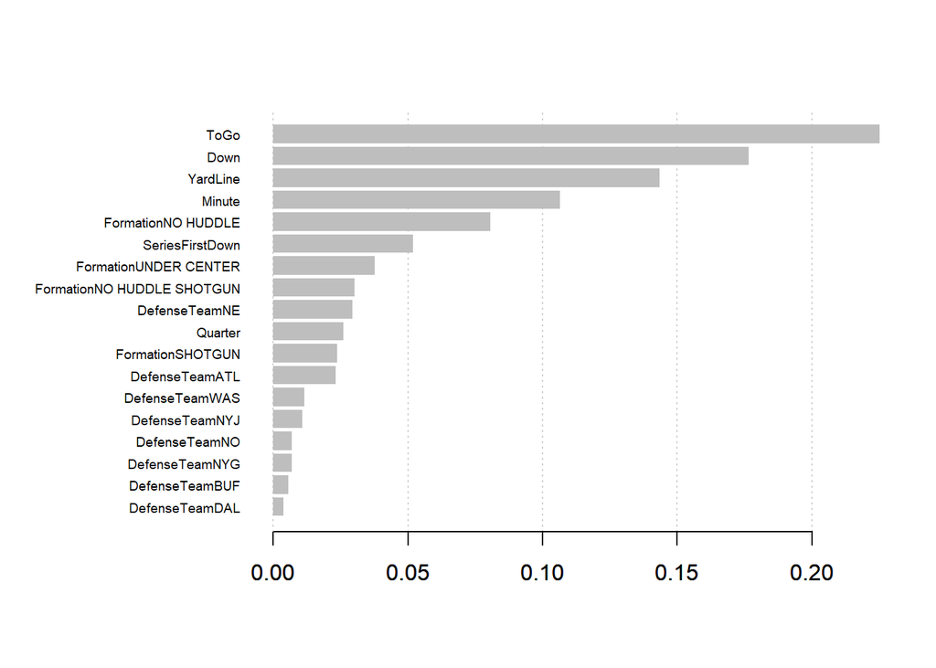

```r
library(useful)
library(xgboost)

xgb.plot.importance(xgb.importance(playBoost, feature_names=colnames(playX_train)))
```

```r
library(dygraphs)

dygraph(playBoost$evaluation_log)
```

[interactive chart not shown]

[figure not shown]